# EDA Project - Diamond Prices (Part 3)

Toavina Andriamanerasoa

31 March 2016

## Problem 1 - Create a histogram of diamond prices. Facet the histogram by diamon color and use cut to color the histogram bars

```r
#install.packages(ggplot2) #<- Unquote if ggplot2 is not installed
#install.packages(ggplot2) #<- Unquote if dplyr is not installed
library(ggplot2)
library(dplyr)
data(diamonds)
names(diamonds)
```

```
##  [1] "carat"   "cut"     "color"   "clarity" "depth"   "table"   "price"
##  [8] "x"       "y"       "z"
```

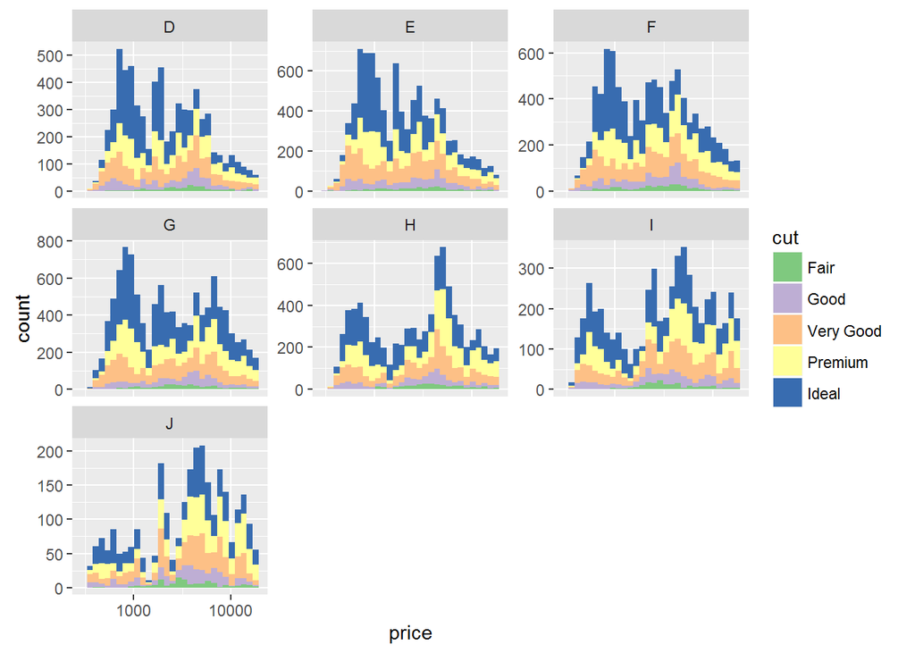

```r
ggplot(data = diamonds, aes(x = price, fill = cut))+
  geom_histogram()+
  facet_wrap(~color, scales = "free_y")+
  scale_fill_brewer(type = 'qual', palette = 'Accent')+
  scale_x_log10()
```

## Problem 2 - Create a scatterplot of diamond price vs. table and color the points by the cut of the diamond

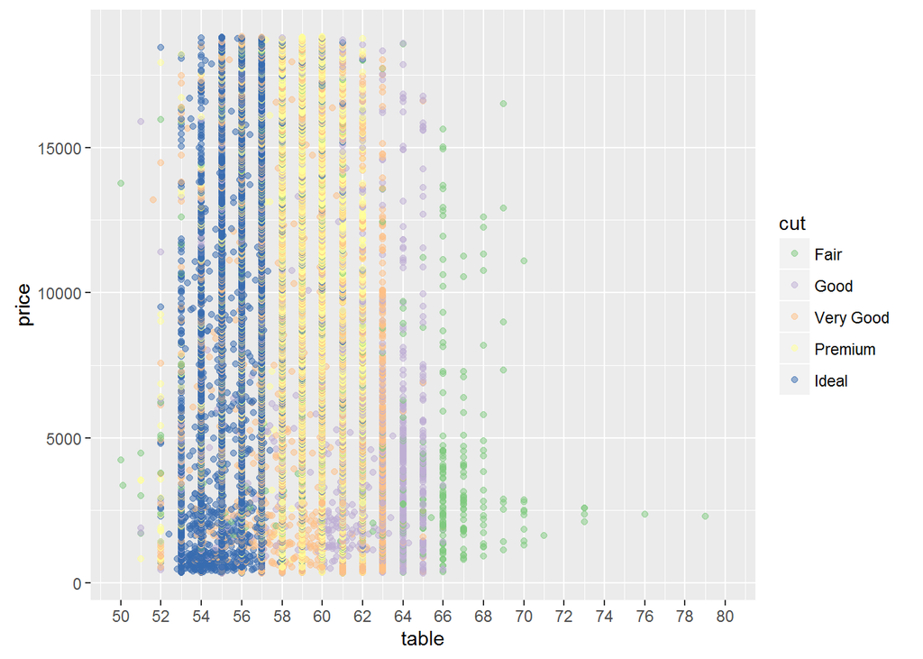

```r
#Note - I'm not showing outliers in the chart
ggplot(data = diamonds, aes(x = table, y = price, color = cut))+
  geom_point(alpha = 1/2)+
  scale_color_brewer(type = 'qual', palette = 'Accent')+
  scale_x_continuous(limits=c(50,80), breaks = seq(50,80,2))
```

**Please note that for the answers below it was asked that the graph was used rather than running code**

### What is the typical range for the majority of diamonds of **ideal** cut?

53 and 57

### What is the typical range for the majority of diamonds of **premium** cut?

58 to 62

## Problem 3 - Create a scatterplot of diamond price vs. volume (x,y,z) and color the points by the clarity of the diamonds. Use scale on the y-axis to take the log10 of price. You should also omit the top 1% of diamond volumes from the plot

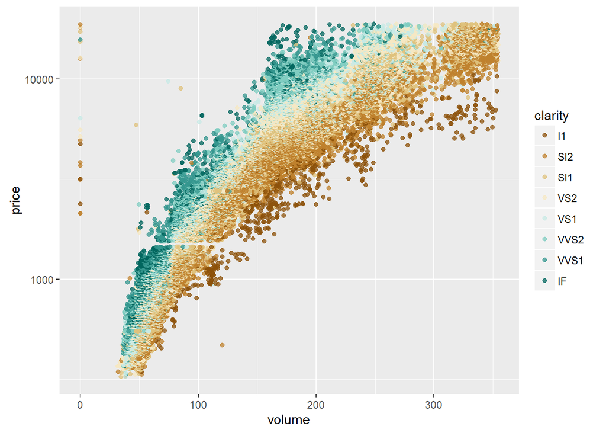

```r
diamonds$volume <- with(diamonds, x*y*z)

ggplot(data = subset(diamonds, volume < quantile(diamonds$volume, probs = 0.99)),
       aes(x = volume, y = price, color = clarity))+
  geom_point(alpha = 0.75)+
  scale_y_continuous(trans = "log10")+
  scale_color_brewer(type = 'div')
```

## Problem 4 - Create a new variable called ‘prop_initiated’ in the Pseudo-Facebook data set. The variable should contain the proportion of friendships that the user initiated

```r
pf <- read.delim('pseudo_facebook.tsv')
pf$prop_initiated <- pf$friendships_initiated / pf$friend_count
```

## Problem 5 - Create a line graph of the median proportion of friendships initiated vs. tenure and color the line segment by year_joined.bucket

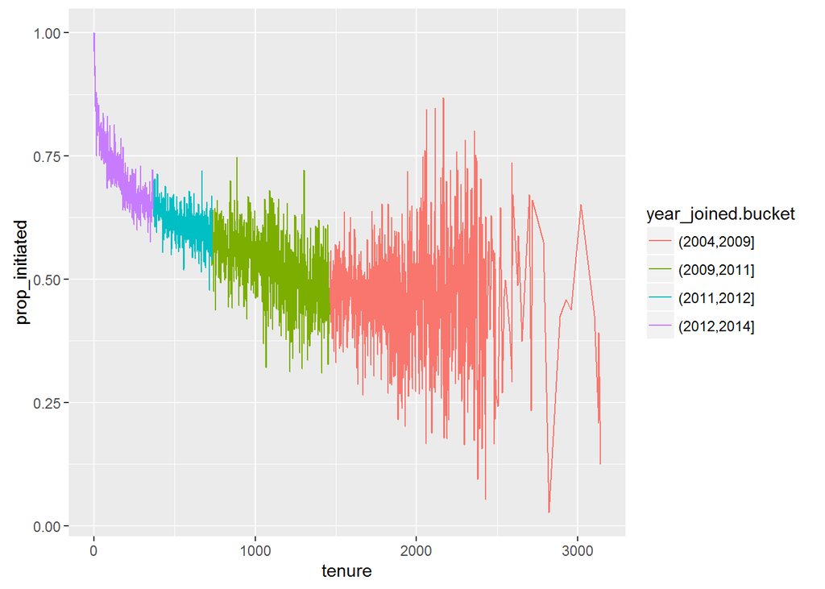

```r
# Create the year joined bucket variable
pf$year_joined <- floor(2014 - pf$tenure/365)
pf$year_joined.bucket <- cut(pf$year_joined, c(2004, 2009, 2011, 2012, 2014))

ggplot(data = subset(pf, !is.na(prop_initiated)),
       aes(x = tenure, y = prop_initiated))+
  geom_line(stat = 'summary', fun.y = median, aes(color = year_joined.bucket))
```

## Problem 6 - Smooth the last plot you created - you can bin together ranges of tenure or add a smoother to the plot

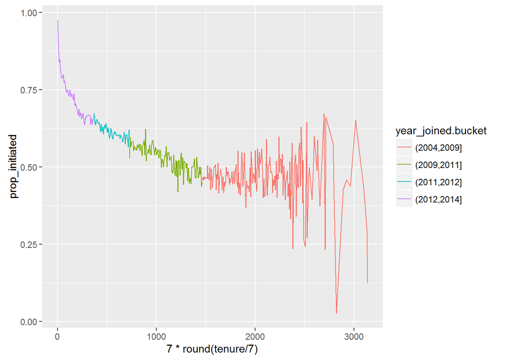

```r
ggplot(data = subset(pf, !is.na(prop_initiated)),
       aes(x = 7*round(tenure/7), y = prop_initiated))+
  geom_line(stat = 'summary', fun.y = median, aes(color = year_joined.bucket))
```

### On average, which group initiated the greatest proportion of its Facebook friendships? The plot with the smoother that you created in the last exercise can help you answer this question

Per the plot, the most recent bucket, i.e. joined after 2012

### For the group with the largest proportion of friendships initiated, what is the group’s average (mean) proportion of friendships initiated?

```r
pf %>%
  select(year_joined.bucket, prop_initiated) %>%
  filter(!is.na(prop_initiated)) %>%
  group_by(year_joined.bucket) %>%
  summarise(average = mean(prop_initiated))
```

```
## Source: local data frame [5 x 2]
##
##   year_joined.bucket   average
##               (fctr)     (dbl)
## 1        (2004,2009] 0.4668151
## 2        (2009,2011] 0.5301298
## 3        (2011,2012] 0.5984577
## 4        (2012,2014] 0.6653892
## 5                 NA 0.6168644
```

Per the output above, the mean for the relevant group’s mean proportion of friendships initiated is c.66.5%

### Why do you think that they have a higher proportion of friendships initiated?

Because users with more tenure typically have larger networks already, so will receive more inbound friend requests than those with less friends.

## Problem 7 - Create a scatter plot of the price/carat ratio of diamonds. The variable x should be assigned to cut. The points should be colored by diamond color, and the plot should be faceted by clarity

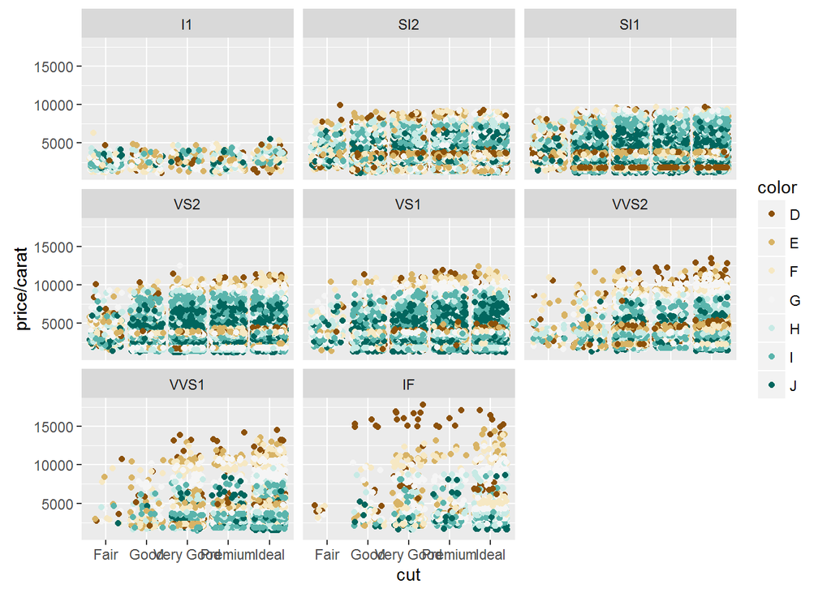

```r
ggplot(data = diamonds,
       aes( x = cut, y = price / carat, color = color))+
  geom_jitter()+
  facet_wrap(~clarity)+
  scale_color_brewer(type = 'div')
```

***

## Gapminder data revisited - Examining additional variables

# Step 1 - Load and tidy the data per previous exercise

```r
# Note - I'm assuming that the relevant libraries are already loaded by preceding code

library(tidyr)

## Load data into dataframes
GDP <- read.csv("GDPpercapitaconstant2000US.csv")
BMI <- read.csv("Indicator_BMI male ASM.csv")

GDP <- tbl_df(GDP)
BMI <- tbl_df(BMI)
```

```r
## Tidy the BMI data by creating a date column
BMI <- BMI %>%
  gather(Year, value = BMI, -Country) %>%
  mutate(Year = as.numeric(substr(Year,2,5)))
```

```r
## Tidy the GDP data by creating a data column
GDP <- GDP %>%
  rename(Country = Income.per.person..fixed.2000.US..) %>%
    gather(Year, value = GDP, -Country) %>%
  mutate(Year = as.numeric(substr(Year,2,5)))
```

```r
## Merge the data together
BMI_GDP <- inner_join(BMI,GDP, by=c("Country","Year"))
## Delete empty observations
BMI_GDP <- BMI_GDP %>%
  filter(!is.na(GDP))
```

## Step 2 - Plot BMI vs. GDP, color by country

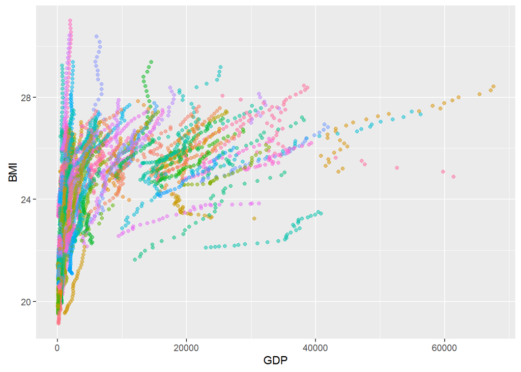

```r
ggplot(data = BMI_GDP, aes(x = GDP, y = BMI, color = Country))+
  geom_point(alpha = 1/2)+
  theme(legend.position = "none")
```

It becomes apparent that there might be a specific relationship for each country.

Here is the chart zooming on the lower GDP per capita country.

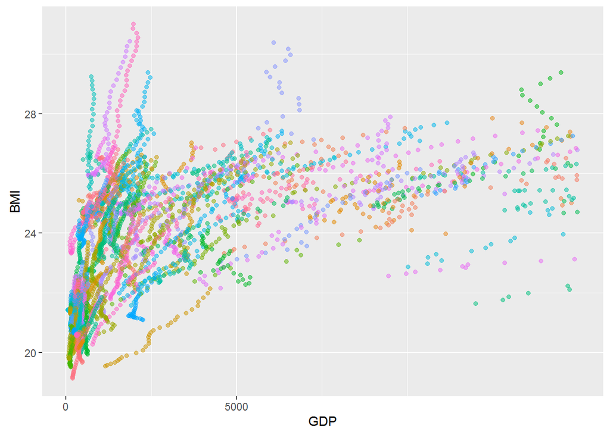

```r
ggplot(data = BMI_GDP, aes(x = GDP, y = BMI, color = Country))+
  geom_point(alpha = 1/2)+
  scale_x_continuous(breaks = c(0,70000,5000), limits = c(50,15000))+
  theme(legend.position = "none")
```

Finally, here is the old chart transforming GDP using a log10 but adding coloring by country

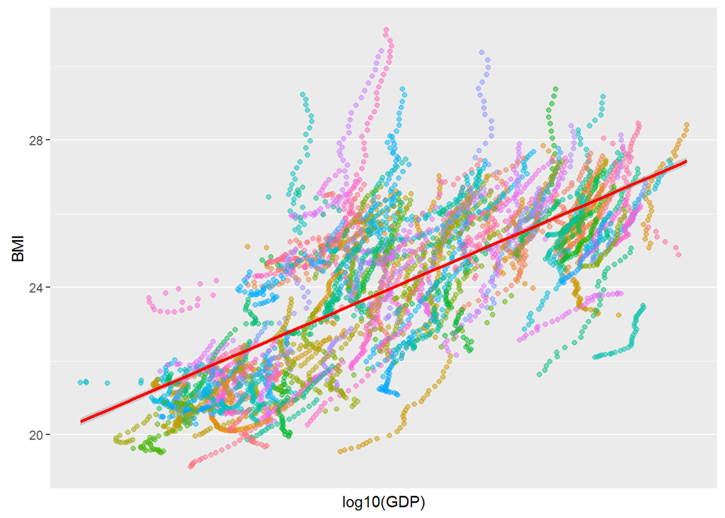

```r
ggplot(data = BMI_GDP, aes(x = log10(GDP), y = BMI, color = Country))+
  geom_point(alpha = 1/2)+
  scale_x_continuous(breaks = c(0,70000,5000))+
  geom_smooth(method = "lm", color = 'red')+
  theme(legend.position = "none")
```